# Generalized Linear Models with the brms R Package

April 27, 2020

## The **brms** Workflow (Figure 1 in Bürkner 2016)

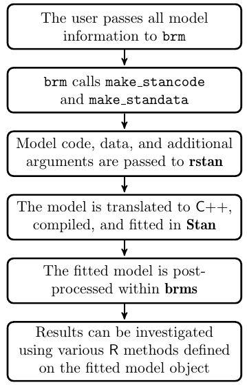

The brms workflow

## The Arguments to `brm`

```r
library(brms)
args(brm)
```

```
## function (formula, data, family = gaussian(), prior = NULL, autocor = NULL,
##     data2 = NULL, cov_ranef = NULL, sample_prior = c("no", "yes",
##         "only"), sparse = NULL, knots = NULL, stanvars = NULL,
##     stan_funs = NULL, fit = NA, save_ranef = TRUE, save_mevars = FALSE,
##     save_all_pars = FALSE, inits = "random", chains = 4, iter = 2000,
##     warmup = floor(iter/2), thin = 1, cores = getOption("mc.cores",
##         1L), control = NULL, algorithm = c("sampling", "meanfield",
##         "fullrank"), future = getOption("future", FALSE), silent = TRUE,
##     seed = NA, save_model = NULL, stan_model_args = list(), save_dso = TRUE,
##     file = NULL, ...)
## NULL
```

## The `formula` Argument to `brm`

- Everything to the right of the `~` is the same as in many other R functions
- In many cases, the thing to the left of the `~` is simply the outcome variable
- However, `brm` introduces a new possibility for this syntax like `y | fun(variable)`, where `fun` could be
  - `cens()` and `trunc()` to specify known censoring or truncation bounds
  - `weights()` and `disp()`, which should not be used with MCMC
  - `se()` to specify “known” standard errors in meta-analyses
  - `trials()`, which is used in binomial models only
  - `cat()` to specify the possible categories for ordinal models

## The `family` Argument to `brm`

The `family` argument can be any of the following functions, which also have a link argument that can be a variety of things depending on the family

```r
gaussian; student; binomial; bernoulli; poisson; negbinomial; geometric; Gamma;
skew_normal; lognormal; shifted_lognormal; exgaussian; wiener; inverse.gaussian;
exponential; weibull; frechet; Beta; dirichlet; von_mises; asym_laplace;
gen_extreme_value; categorical; multinomial; cumulative; cratio; sratio; acat;
hurdle_poisson; hurdle_negbinomial; hurdle_gamma; hurdle_lognormal;
zero_inflated_binomial; zero_inflated_beta; zero_inflated_negbinomial;
zero_inflated_poisson; zero_one_inflated_beta
```

- The ones involving `hurdle_`, `zero_inflated_` and / or `negbinomial` are of particular interest in the social sciences

## Prior Predictive Distribution for Roach Study

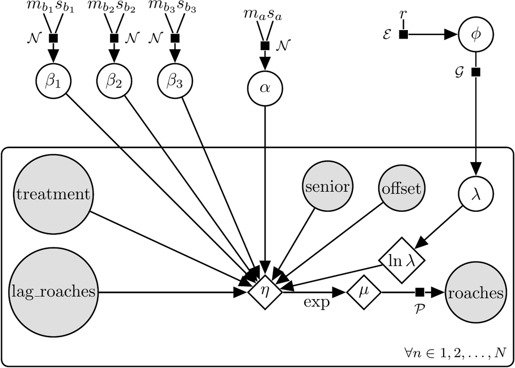

Roach Model

## Stan Code for this Prior Predictive Distribution

```stan
functions {
  matrix roaches_PPD_rng(int S, vector log_roach1, vector treatment,
                         vector senior, vector offset) {
    int N = rows(log_roach1);
    matrix[S, N] PPD;
    for (s in 1:S) {
      real alpha = normal_rng(0, 5);
      real beta[3] = normal_rng([0,0,0], 2);
      real phi[N] = rep_array(exponential_rng(1), N);
      real lambda[N] = gamma_rng(phi, phi);
      vector[N] log_lambda = to_vector(log(lambda));
      vector[N] eta = alpha + offset + beta[1] * log_roach1 +
        beta[2] * treatment + beta[3] * senior + log_lambda;
      vector[N] mu = exp(eta);
      PPD[s, ] = to_row_vector(poisson_rng(mu));
    }
    return PPD;
  }
}
```

## Breakout Rooms

```r
data(roaches, package = "rstanarm"); roaches <- roaches[roaches$roach1 > 0, ]; str(roaches)
```

```
## 'data.frame':    202 obs. of  5 variables:
##  $ y        : int  153 127 7 7 0 73 24 2 2 0 ...
##  $ roach1   : num  308 331.25 1.67 3 2 ...
##  $ treatment: int  1 1 1 1 1 1 1 0 0 0 ...
##  $ senior   : int  0 0 0 0 0 0 0 0 0 0 ...
##  $ exposure2: num  0.8 0.6 1 1 1.14 ...
```

- Call `rstan::expose_stan_functions` on a .stan file with the previous code
- Call `roaches_PPD_rng` with `S = 1`, `log_roach1 = log(roaches$roach1)`, and `offset = log(exposure2)`
- Is this prior predictive distribution of roaches reasonable in the sense that it is similar to `roaches$roach1`?
- If not, modify the priors in the previous code to make the prior predictive distribution reasonable

## Integral Leading to Negative Binomial

- Now let \(\eta_n = \alpha + \sum_{k = 1}^K \beta_k x_{nk}\) without \(\log \lambda_n\)
- Poisson likelihood is \(\mathcal{L}\left(\eta_n, \lambda_n; y_n\right) \propto \left(\lambda_n e^{\eta_n}\right)^{y_n} e^{-\lambda_n e^{\eta_n}} = \lambda_n^{y_n} \left(e^{\eta_n}\right)^{y_n} e^{-\lambda_n e^{\eta_n}}\)
- Gamma prior is \(f\left(\lambda_n \mid \phi\right) \propto \lambda_n^{\phi - 1} e^{-\phi \lambda_n}\)
- Integrating \(\lambda_n\) out of the product yields \[\int_0^\infty \lambda_n^{y_n} \left(e^{\eta_n}\right)^{y_n} e^{-\lambda_n e^{\eta_n}} \lambda_n^{\phi - 1} e^{-\phi \lambda_n} d\lambda_n \propto \\ {y_n + \phi - 1 \choose y_n} \left(\frac{e^{\eta_n}}{e^{\eta_n} + \phi}\right)^{y_n} \left(\frac{\phi}{e^{\eta_n} + \phi}\right)^\phi\] which is the PMF of the negative binomial distribution

## Equivalent Prior Predictive Distribution

```stan
functions {
  matrix roaches_PPD_rng(int S, vector log_roach1, vector treatment,
                         vector senior, vector offset) {
    int N = rows(log_roach1);
    matrix[S, N] PPD;
    for (s in 1:S) {
      real alpha = normal_rng(0, 5);
      real beta[3] = normal_rng([0,0,0], 2);
      real phi = exponential_rng(1);
      vector[N] eta = alpha + offset + beta[1] * log_roach1 +
        beta[2] * treatment + beta[3] * senior;
      PPD[s, ] = to_row_vector(neg_binomial_2_log_rng(eta, phi));
    }
    return PPD;
  }
}
```

## The `prior` Argument to `brm`

```r
args(set_prior) # or just prior()
```

```
## function (prior, class = "b", coef = "", group = "", resp = "",
##     dpar = "", nlpar = "", lb = NA, ub = NA, check = TRUE)
## NULL
```

- `prior` is a character string (in the Stan language) such as `"normal(0,5)"`
- `class` indicates what parameters the call to `set_prior` pertains to
- `coef` is the name of the parameter in question
- `group` is the name of the grouping factor (if applicable)
- `resp` is the name of the response variable in multivariate models
- `dpar` is the name of the distribution parameter (if applicable)
- `nlpar` is the name of the non-linear parameter (if applicable)
- `lb` is the lower bound of the parameter (default \(-\infty\))
- `ub` is the upper bound of the parameter (default \(\infty\))
- `check` whether priors should be checked for validity

## The `get_prior` Function

- Input the `formula`, `data`, and `family` and get back the possible prior choices (and defaults)

```r
get_prior(y ~ log(roach1) + treatment + senior + offset(log(exposure2)),
          data = roaches, family = negbinomial)
```

```
##                 prior     class      coef group resp dpar nlpar bound
## 1                             b
## 2                             b logroach1
## 3                             b    senior
## 4                             b treatment
## 5 student_t(3, 2, 10) Intercept
## 6   gamma(0.01, 0.01)     shape
```

## The `class` Argument to `set_prior`

- Refers to a type of parameter in the model
- Defaults to `"b"` which refers to (population-level) regression coefficients
- Other possible values are `"Intercept"`, `"sd"`, `"cor"`, `"sigma"` and others we may talk about later

```r
my_prior <- prior(cauchy(0, 1), class = "b")
```

- If you call `prior` rather than `set_prior`, the first argument can be an R expression rather than a character string

## Example of `brm`

```r
post <- brm(y ~ log(roach1) + treatment + senior + offset(log(exposure2)),
            data = roaches, family = negbinomial, prior = prior(normal(0, 2), class = "b") +
            prior(normal(0, 5), class = "Intercept") + prior(exponential(1), class = "shape"))
```

```r
post
```

```
...
##           Estimate Est.Error l-95% CI u-95% CI Rhat Bulk_ESS Tail_ESS
## Intercept     1.33      0.26     0.85     1.83 1.00     4632     3367
## logroach1     0.70      0.06     0.57     0.82 1.00     4605     3291
## treatment    -0.62      0.21    -1.04    -0.20 1.00     4659     3060
## senior       -0.20      0.25    -0.66     0.29 1.00     4576     3133
##
## Family Specific Parameters:
##       Estimate Est.Error l-95% CI u-95% CI Rhat Bulk_ESS Tail_ESS
## shape     0.47      0.05     0.38     0.58 1.00     4659     3011
##
## Samples were drawn using sampling(NUTS). For each parameter, Bulk_ESS
## and Tail_ESS are effective sample size measures, and Rhat is the potential
## scale reduction factor on split chains (at convergence, Rhat = 1).
...
```

## Using the `loo` Function

- McElreath cautions against using things like `loo` when \(\lambda_n\) is included
- If \(\lambda_n\) is integrated out of the posterior distribution by using a negative binomial likelihood, everything’s fine (unless there are warnings, in which case `reloo`)

```r
loo_post <- loo(post, reloo = TRUE) # observation 85 has a Pareto k > 0.7
loo_post
```

```
##
## Computed from 4000 by 202 log-likelihood matrix
##
##          Estimate   SE
## elpd_loo   -759.3 28.3
## p_loo         5.3  1.5
## looic      1518.6 56.6
## ------
## Monte Carlo SE of elpd_loo is 0.1.
##
## Pareto k diagnostic values:
##                          Count Pct.    Min. n_eff
## (-Inf, 0.5]   (good)     201   99.5%   1110
##  (0.5, 0.7]   (ok)         1    0.5%   293
##    (0.7, 1]   (bad)        0    0.0%   <NA>
##    (1, Inf)   (very bad)   0    0.0%   <NA>
##
## All Pareto k estimates are ok (k < 0.7).
## See help('pareto-k-diagnostic') for details.
```

## Using the `pp_check` Function

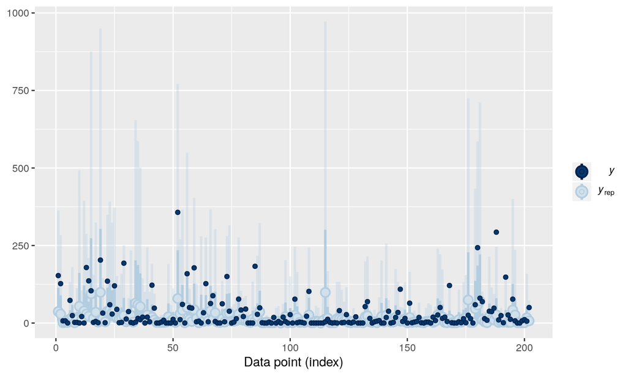

```r
pp_check(post, type = "loo_intervals") # type is the same as plotfun with rstanarm
```

## Using the `hypothesis` Function

- To do this with **rstanarm**, you would have to first call `as.matrix`

```r
args(brms:::hypothesis.brmsfit)
```

```
## function (x, hypothesis, class = "b", group = "", scope = c("standard",
##     "ranef", "coef"), alpha = 0.05, seed = NULL, ...)
## NULL
```

- Here `x` is the object produced by `brm` and `hypothesis` is a string, typically with an embedded `<` or `>`, such as

```r
hypothesis(post, "treatment < 0")
```

```
## Hypothesis Tests for class b:
##        Hypothesis Estimate Est.Error CI.Lower CI.Upper Evid.Ratio Post.Prob Star
## 1 (treatment) < 0    -0.62      0.21    -0.98    -0.27        399         1    *
## ---
## 'CI': 90%-CI for one-sided and 95%-CI for two-sided hypotheses.
## '*': For one-sided hypotheses, the posterior probability exceeds 95%;
## for two-sided hypotheses, the value tested against lies outside the 95%-CI.
## Posterior probabilities of point hypotheses assume equal prior probabilities.
```

## Other Post-Estimation Methods

Many of the things you can do with an object produced by `brm` are analagous to **rstanarm**

```
##       [,1]                  [,2]                      [,3]
##  [1,] "add_criterion"       "loo_compare"             "posterior_samples"
##  [2,] "add_ic"              "loo_linpred"             "posterior_summary"
##  [3,] "as.array"            "loo_model_weights"       "pp_average"
##  [4,] "as.data.frame"       "loo_predict"             "pp_check"
##  [5,] "as.matrix"           "loo_predictive_interval" "pp_expect"
##  [6,] "as.mcmc"             "loo_R2"                  "pp_mixture"
##  [7,] "autocor"             "loo_subsample"           "predict"
##  [8,] "bayes_factor"        "loo"                     "predictive_error"
##  [9,] "bayes_R2"            "LOO"                     "predictive_interval"
## [10,] "bridge_sampler"      "marginal_effects"        "print"
## [11,] "coef"                "marginal_smooths"        "prior_samples"
## [12,] "conditional_effects" "mcmc_plot"               "prior_summary"
## [13,] "conditional_smooths" "model_weights"           "ranef"
## [14,] "control_params"      "model.frame"             "reloo"
## [15,] "expose_functions"    "neff_ratio"              "residuals"
## [16,] "extract_draws"       "ngrps"                   "rhat"
## [17,] "family"              "nobs"                    "stancode"
## [18,] "fitted"              "nsamples"                "standata"
## [19,] "fixef"               "nuts_params"             "stanplot"
## [20,] "formula"             "pairs"                   "summary"
## [21,] "getCall"             "parnames"                "update"
## [22,] "hypothesis"          "plot"                    "VarCorr"
## [23,] "kfold"               "post_prob"               "vcov"
## [24,] "launch_shinystan"    "posterior_average"       "waic"
## [25,] "log_lik"             "posterior_interval"      "WAIC"
## [26,] "log_posterior"       "posterior_linpred"       ""
## [27,] "logLik"              "posterior_predict"       ""
```

## Breakout Rooms: Hurdle Models

- Hurdle models combine a logit model for whether there is a positive number of roaches in a building with a negative binomial model for the number of roaches, conditional on there being at least 1 roach
- Augment previous Stan code to draw from its prior predictive distribution of a hurdle model
- Hints: You are going to have to loop from `1` to `N` and do the two parts inside an inner loop instead of vectorizing the whole thing. Also, you will need a `while` loop to enforce the constraint that the draw from the negative binomial distribution is not zero.

```r
get_prior(brms::bf(y ~ log(roach1) + treatment + senior + offset(log(exposure2)),
                   hu ~ I(roach1 == 0) + treatment + senior), data = roaches,
          family = hurdle_negbinomial)
```

```
##                  prior     class             coef group resp dpar nlpar bound
## 1                              b
## 2                              b        logroach1
## 3                              b           senior
## 4                              b        treatment
## 5  student_t(3, 2, 10) Intercept
## 6    gamma(0.01, 0.01)     shape
## 7                              b                               hu
## 8                              b Iroach1EQEQ0TRUE              hu
## 9                              b           senior              hu
## 10                             b        treatment              hu
## 11      logistic(0, 1) Intercept                               hu
```

## Hurdle Models with `brm`

```r
post_hurdle <- brm(brms::bf(y ~ log(roach1) + treatment + senior + offset(log(exposure2)),
                            hu ~ I(roach1 == 0) + treatment + senior), data = roaches,
                   family = hurdle_negbinomial, seed = 12345, prior =
                     prior(normal(0, 2), class = "b") +
                     prior(normal(0, 5), class = "Intercept") +
                     prior(exponential(1), class = "shape") +
                     prior(normal(0, 2), class = "b", dpar = "hu"))
```

## Results of Hurdle Model

```r
post_hurdle
```

```
...
## Population-Level Effects:
##                     Estimate Est.Error l-95% CI u-95% CI Rhat Bulk_ESS Tail_ESS
## Intercept               1.64      0.28     1.10     2.17 1.00     6474     2918
## hu_Intercept           -1.59      0.30    -2.20    -1.03 1.00     7704     3057
## logroach1               0.61      0.07     0.48     0.74 1.00     6325     2624
## treatment              -0.50      0.21    -0.94    -0.09 1.00     7225     2604
## senior                 -0.04      0.27    -0.55     0.51 1.00     7097     2985
## hu_Iroach1EQEQ0TRUE    -0.05      1.98    -3.86     3.82 1.00     7064     3017
## hu_treatment            0.39      0.36    -0.31     1.09 1.00     7444     3259
## hu_senior               0.81      0.35     0.13     1.49 1.00     5904     2728
##
## Family Specific Parameters:
##       Estimate Est.Error l-95% CI u-95% CI Rhat Bulk_ESS Tail_ESS
## shape     0.64      0.11     0.44     0.87 1.00     5899     2838
##
## Samples were drawn using sampling(NUTS). For each parameter, Bulk_ESS
## and Tail_ESS are effective sample size measures, and Rhat is the potential
## scale reduction factor on split chains (at convergence, Rhat = 1).
...
```

## PSISLOOCV Comparison

```r
loo(post, post_hurdle, reloo = TRUE)
```

```
## Output of model 'post':
##
## Computed from 4000 by 202 log-likelihood matrix
##
##          Estimate   SE
## elpd_loo   -759.3 28.3
## p_loo         5.3  1.5
## looic      1518.6 56.6
## ------
## Monte Carlo SE of elpd_loo is 0.1.
##
## Pareto k diagnostic values:
##                          Count Pct.    Min. n_eff
## (-Inf, 0.5]   (good)     201   99.5%   1110
##  (0.5, 0.7]   (ok)         1    0.5%   293
##    (0.7, 1]   (bad)        0    0.0%   <NA>
##    (1, Inf)   (very bad)   0    0.0%   <NA>
##
## All Pareto k estimates are ok (k < 0.7).
## See help('pareto-k-diagnostic') for details.
##
## Output of model 'post_hurdle':
##
## Computed from 4000 by 202 log-likelihood matrix
##
##          Estimate   SE
## elpd_loo   -773.0 27.9
## p_loo         8.1  1.5
## looic      1546.0 55.9
## ------
## Monte Carlo SE of elpd_loo is 0.1.
##
## Pareto k diagnostic values:
##                          Count Pct.    Min. n_eff
## (-Inf, 0.5]   (good)     201   99.5%   3096
##  (0.5, 0.7]   (ok)         1    0.5%   366
##    (0.7, 1]   (bad)        0    0.0%   <NA>
##    (1, Inf)   (very bad)   0    0.0%   <NA>
##
## All Pareto k estimates are ok (k < 0.7).
## See help('pareto-k-diagnostic') for details.
##
## Model comparisons:
##             elpd_diff se_diff
## post          0.0       0.0
## post_hurdle -13.7       4.9
```

## Simplexes

- Let \(X_1, X_2, \dots X_K\) be defined for a sample space \(\Omega\) or a parameter space \(\Theta\) such that \(X_k \geq 0 \forall k\) and \(\sum_{k = 1}^K X_k = 1\)
- Then \(X_1, X_2, \dots X_K\) are said to be a simplex, which is essentially a PMF
- The constraint that \(\sum_{k = 1}^K X_k = 1\) implies \(X_i\) is NOT independent of \(X_j\)
- The cumulative sum of a simplex is often useful and implies the last element is exactly \(1\) while all the previous elements are between \(0\) and \(1\)

## Categorical Distribution

- The categorical distribution over \(\Omega = \{1,2,\dots,K\}\) has a PMF \(\Pr\left(\left.x\right|\pi_1,\pi_2,\dots,\pi_K\right) = \prod_{k=1}^K \pi_k^{\mathbb{I}\left(x=k\right)}\) where the parameters satisfy
  1. \(\pi_k \geq 0 \forall k\)
  2. \(\sum_{k=1}^K \pi_k = 1\)
- The categorical distribution is a generalization of the Bernoulli distribution to the case where there are \(K\) categories rather than merely failure vs. success
- To draw randomly from it, you can do `sample(Omega, size = 1, prob = c(pi_1, pi_2, ..., pi_K))`
- You can make each \(\pi_k\) a function of predictors in a regression model

## Multinomial Distribution

- The multinomial distribution over \(\Omega = \{0,1,\dots,n\}\) has a PMF \(\Pr\left(\left.x\right|\pi_1,\pi_2,\dots,\pi_K\right) = n!\prod_{k=1}^K \frac{\pi_k^{x_k}}{x_k!}\) where the parameters satisfy \(\pi_k \geq 0 \forall k\), \(\sum_{k=1}^K \pi_k = 1\), and \(n = \sum_{k=1}^K x_k\)
- The multinomial distribution is a generalization of the binomial distribution to the case that there are \(K\) possibilities rather than merely failure vs. success
- The multinomial distribution is the count of \(n\) independent categorical random variables with the same \(\pi_k\) values
- Can draw from it with `rmultinom(1, size = n, prob = c(pi_1, pi_2, ..., pi_K))`
- Categorical is a special case where \(n = 1\)

## Graphs of Standard Normal Utility with Cutpoints

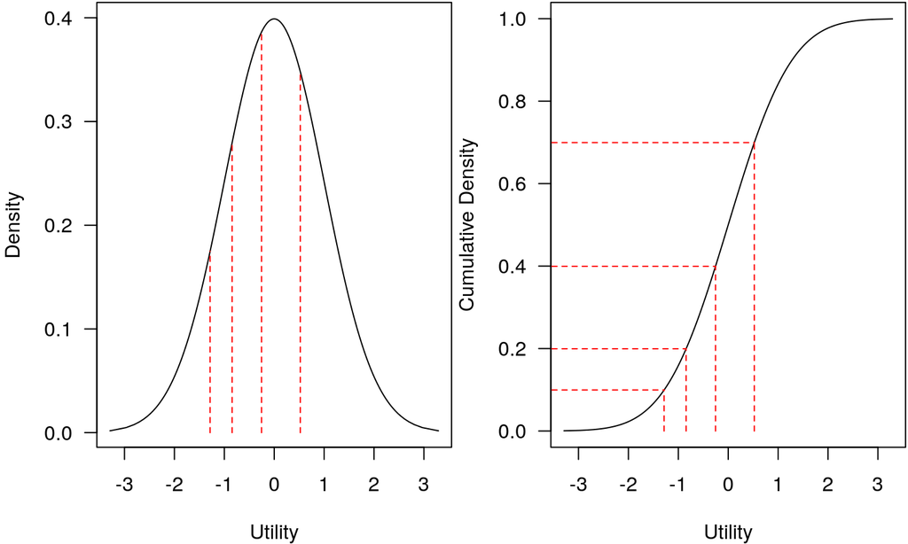

## Likelihood for an Ordered Observation

- Likelihood for an observation is just categorical: \(\mathcal{L}\left(\beta, \boldsymbol{\zeta};y\right) \propto\prod_{j=1}^{J}\Pr\left(\left.y=j\right|\beta, \boldsymbol{\zeta}\right)\)
- If \(F\left(\right)\) is in the location-scale family (normal, logistic, etc.), then \(F\left(\beta x +\epsilon\leq\zeta_{j}\right)=F_{0,1}\left(\zeta_{j}-\beta x\right)\), where \(F_{0,1}\left(\right)\) is the “standard” version of the CDF
- \(\Pr\left(\left.y=j\right|\beta, \boldsymbol{\zeta}\right) = F\left(\beta x +\epsilon\leq\zeta_{j}\right) - F\left(\beta x +\epsilon\leq\zeta_{j - 1}\right)\)

## Prior Predictive Distribution of an Ordinal Model

\[\forall k: \beta_k \thicksim ??? \\ \forall n: \eta_n = \sum_{k = 1}^K \beta_k x_{nk} \\ \zeta_1 \thicksim ??? \\ \forall 1 < j < J - 1:\zeta_j - \zeta_{j - 1} \thicksim ??? \\ \forall n: \epsilon_n \thicksim \mathcal{N}\left(0,1\right) \\ \forall n: u_n = \eta_n + \epsilon_n \\ \forall n: y_n = 1 + \sum_{j = 1}^{J - 1} \mathcal{I}\{u_n > \zeta_j\}\]

## Estimating an Ordinal Model with `stan_polr`

```r
library(rstanarm); options(mc.cores = parallel::detectCores())
data("inhaler", package = "brms")
inhaler$rating <- as.ordered(inhaler$rating)
post <- stan_polr(rating ~ treat + period + carry, data = inhaler,
                  method = "probit", prior = R2(0.25), seed = 12345)
```

- Now we can estimate the causal effect of `treat` on utility for `rating`:

```r
nd <- inhaler; nd$treat <- 1
y1_star <- posterior_linpred(post, newdata = nd)
nd$treat <- 0
y0_star <- posterior_linpred(post, newdata = nd)
summary(c(y1_star - y0_star))
```

```
##     Min.  1st Qu.   Median     Mean  3rd Qu.     Max.
## -0.99207 -0.58247 -0.48490 -0.48631 -0.38750  0.06511
```

## Results

```
...
## ------
##        Median MAD_SD
## treat  -0.48   0.14
## period  0.12   0.11
## carry  -0.12   0.10
##
## Cutpoints:
##     Median MAD_SD
## 1|2 0.33   0.05
## 2|3 1.77   0.10
## 3|4 2.28   0.13
##
...
```

## Similar Models with `brm`

- `brm` can estimate similar models, but with priors on the coefficients

```r
po <- brm(rating ~ treat + period + carry,
            data = inhaler, family = cumulative) # similar to rstanarm::stan_polr
sr <- brm(formula = rating ~ period + carry + cs(treat), data = inhaler,
            family = sratio, prior = prior(normal(-1, 2), coef = "treat"))
```

- Latter model considers when a person “stops” and allows the effect of `treat` to vary across categories of `rating`

## `loo` to the Rescue

```r
loo(po, sr)
```

```
## Output of model 'po':
##
## Computed from 4000 by 572 log-likelihood matrix
##
##          Estimate   SE
## elpd_loo   -459.0 17.2
## p_loo         6.0  0.5
## looic       917.9 34.5
## ------
## Monte Carlo SE of elpd_loo is 0.0.
##
## All Pareto k estimates are good (k < 0.5).
## See help('pareto-k-diagnostic') for details.
##
## Output of model 'sr':
##
## Computed from 4000 by 572 log-likelihood matrix
##
##          Estimate   SE
## elpd_loo   -459.5 17.5
## p_loo         8.1  1.2
## looic       919.1 35.1
## ------
## Monte Carlo SE of elpd_loo is 0.1.
##
## All Pareto k estimates are good (k < 0.5).
## See help('pareto-k-diagnostic') for details.
##
## Model comparisons:
##    elpd_diff se_diff
## po  0.0       0.0
## sr -0.6       2.0
```

## Results of Cumulative Model

```r
po
```

```
...
##              Estimate Est.Error l-95% CI u-95% CI Rhat Bulk_ESS Tail_ESS
## Intercept[1]     0.55      0.09     0.38     0.72 1.00     5398     3477
## Intercept[2]     3.23      0.20     2.85     3.62 1.00     6138     2803
## Intercept[3]     4.49      0.36     3.84     5.23 1.00     5894     3050
## treat           -0.80      0.25    -1.29    -0.31 1.00     3292     3195
## period           0.18      0.18    -0.15     0.54 1.00     5089     2794
## carry           -0.22      0.18    -0.58     0.14 1.00     3054     3110
##
## Samples were drawn using sampling(NUTS). For each parameter, Bulk_ESS
## and Tail_ESS are effective sample size measures, and Rhat is the potential
## scale reduction factor on split chains (at convergence, Rhat = 1).
...
```

## Results of Stopping Ratio Model

```r
sr
```

```
...
##              Estimate Est.Error l-95% CI u-95% CI Rhat Bulk_ESS Tail_ESS
## Intercept[1]     0.55      0.09     0.38     0.73 1.00     4905     2942
## Intercept[2]     2.40      0.29     1.88     3.01 1.00     3198     2431
## Intercept[3]     0.68      0.56    -0.39     1.81 1.00     3754     3325
## period           0.22      0.17    -0.11     0.55 1.00     3985     2843
## carry           -0.21      0.17    -0.53     0.11 1.00     3739     3196
## treat[1]        -0.78      0.23    -1.24    -0.34 1.00     3790     2767
## treat[2]        -1.08      0.57    -2.29    -0.04 1.00     3047     2443
## treat[3]         0.61      1.02    -1.42     2.56 1.00     3482     3122
##
## Samples were drawn using sampling(NUTS). For each parameter, Bulk_ESS
## and Tail_ESS are effective sample size measures, and Rhat is the potential
## scale reduction factor on split chains (at convergence, Rhat = 1).
...
```

## Models with Ordinal Predictors

- Often but not always it is reasonable to assume that the coefficients on dummy variables derived from the same ordered factor are monotonic

```r
theta <- MCMCpack::rdirichlet(n = 1, alpha = c(1, 1, 1))[1, ] # PDF over PMFs
rbind(theta, cumsum(theta))
```

```
##            [,1]      [,2]      [,3]
## theta 0.1071258 0.7715094 0.1213648
##       0.1071258 0.8786352 1.0000000
```

```r
gamma <- rnorm(n = 1)
beta <- gamma * cumsum(theta)
```

- This is what **brms** does when you use `mo(ordered_factor)` on the right-hand side of a formula and put a standard normal prior on the scale factor
- For more examples, see https://cran.r-project.org/package=brms/vignettes/brms_monotonic.html

## Ordinal Predictors in Polling

```r
poll <- readRDS("GooglePoll.rds") # WantToWin is coded as 1 for Romney and 0 for Obama
library(dplyr)
collapsed <- filter(poll, !is.na(WantToWin)) %>%
             group_by(Region, Gender, Urban_Density, Age, Income) %>%
             summarize(Romney = sum(grepl("Romney", WantToWin)), Obama = n() - Romney) %>%
             na.omit
```

```r
post <- brm(Romney | trials(Romney + Obama) ~ Region + Gender + Urban_Density +
              # Age and Income are restricted to have monotonic effects
              mo(Age) + mo(Income), data = collapsed, family = binomial)
```

## Results of Model with Ordinal Predictors

```
...
##                       Estimate Est.Error l-95% CI u-95% CI Rhat Bulk_ESS Tail_ESS
## Intercept                -0.63      0.12    -0.86    -0.39 1.00     2795     2754
## RegionNORTHEAST          -0.13      0.09    -0.31     0.04 1.00     3250     2845
## RegionSOUTH               0.31      0.07     0.17     0.45 1.00     3218     2256
## RegionWEST               -0.14      0.08    -0.29     0.00 1.00     2901     3038
## GenderMale                0.39      0.06     0.28     0.50 1.00     4238     2983
## Urban_DensitySuburban    -0.19      0.09    -0.36    -0.02 1.00     3239     2343
## Urban_DensityUrban       -0.50      0.09    -0.68    -0.32 1.00     3071     2643
## moAge                     0.27      0.02     0.23     0.31 1.00     3304     2991
## moIncome                  0.01      0.06    -0.09     0.15 1.00     2007     1465
##
## Simplex Parameters:
##              Estimate Est.Error l-95% CI u-95% CI Rhat Bulk_ESS Tail_ESS
## moAge1[1]        0.09      0.05     0.01     0.21 1.00     2677     1634
## moAge1[2]        0.31      0.07     0.17     0.46 1.00     3641     2696
## moAge1[3]        0.21      0.07     0.07     0.35 1.00     3426     2107
## moAge1[4]        0.05      0.04     0.00     0.14 1.00     3021     1821
## moAge1[5]        0.34      0.06     0.22     0.44 1.00     4552     3398
## moIncome1[1]     0.18      0.17     0.00     0.61 1.00     2630     2155
## moIncome1[2]     0.15      0.14     0.00     0.53 1.00     2591     1561
## moIncome1[3]     0.18      0.15     0.01     0.56 1.00     3729     2463
## moIncome1[4]     0.22      0.18     0.01     0.65 1.00     3508     2236
## moIncome1[5]     0.25      0.20     0.01     0.73 1.00     3102     2386
##
## Samples were drawn using sampling(NUTS). For each parameter, Bulk_ESS
## and Tail_ESS are effective sample size measures, and Rhat is the potential
## scale reduction factor on split chains (at convergence, Rhat = 1).
...
```

## Effects Plot

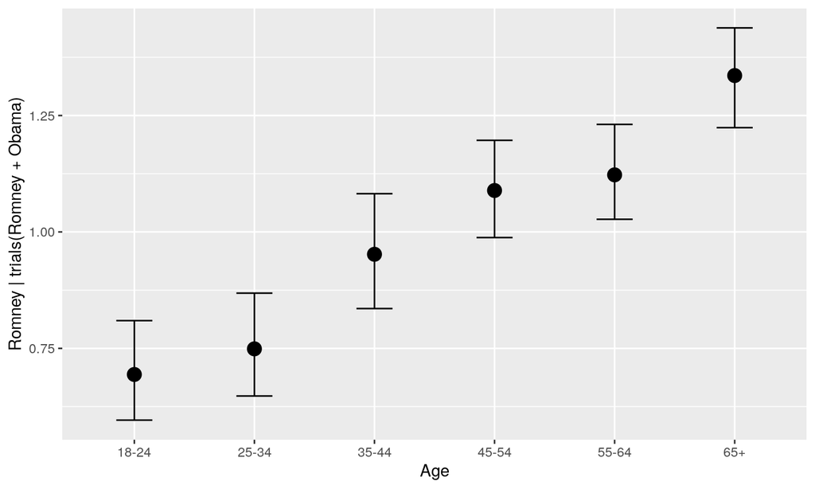

```r
plot(conditional_effects(post, effects = "Age"))
```